# Statistical Inference Course Project

Yan

5/8/2018

## Part 1: Simulation Exercise Instructionsless

In this project you will investigate the exponential distribution in R and compare it with the Central Limit Theorem. The exponential distribution can be simulated in R with rexp(n, lambda) where lambda is the rate parameter. The mean of exponential distribution is 1/lambda and the standard deviation is also 1/lambda. Set lambda = 0.2 for all of the simulations. You will investigate the distribution of averages of 40 exponentials. Note that you will need to do a thousand simulations.

Illustrate via simulation and associated explanatory text the properties of the distribution of the mean of 40 exponentials. You should

1. Show the sample mean and compare it to the theoretical mean of the distribution.
2. Show how variable the sample is (via variance) and compare it to the theoretical variance of the distribution.
3. Show that the distribution is approximately normal.

In point 3, focus on the difference between the distribution of a large collection of random exponentials and the distribution of a large collection of averages of 40 exponentials.

*As a motivating example, compare the distribution of 1000 random uniforms*

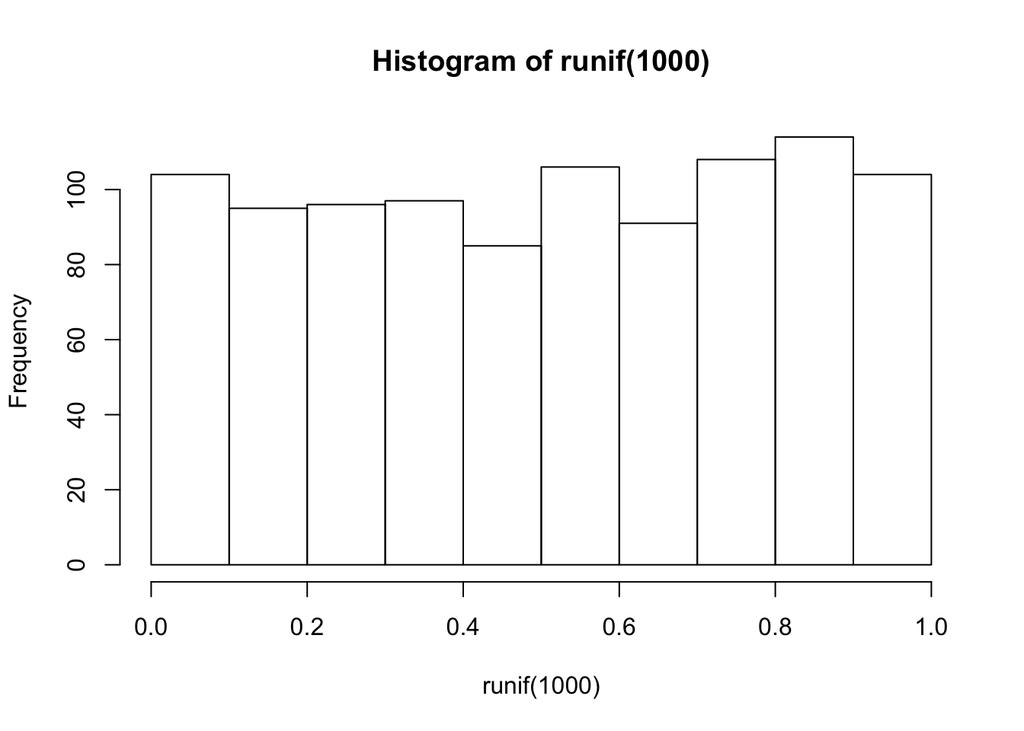

```r
hist(runif(1000))
```

*and the distribution of 1000 averages of 40 random uniforms*

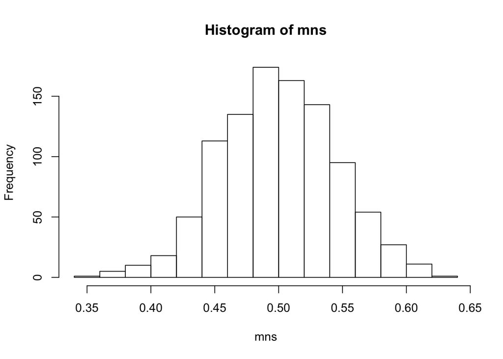

```r
mns = NULL
for (i in 1 : 1000) mns = c(mns, mean(runif(40)))
hist(mns)
```

*This distribution looks far more Gaussian than the original uniform distribution!*

*This exercise is asking you to use your knowledge of the theory given in class to relate the two distributions.*

*Confused? Try re-watching video lecture 07 for a starter on how to complete this project.*

*Sample Project Report Structure*

*Of course, there are multiple ways one could structure a report to address the requirements above. However, the more clearly you pose and answer each question, the easier it will be for reviewers to clearly identify and evaluate your work.*

*A sample set of headings that could be used to guide the creation of your report might be:*

*Title (give an appropriate title) and Author Name*

*Overview: In a few (2-3) sentences explain what is going to be reported on.*

*Simulations: Include English explanations of the simulations you ran, with the accompanying R code. Your explanations should make clear what the R code accomplishes.*

*Sample Mean versus Theoretical Mean: Include figures with titles. In the figures, highlight the means you are comparing. Include text that explains the figures and what is shown on them, and provides appropriate numbers.*

*Sample Variance versus Theoretical Variance: Include figures (output from R) with titles. Highlight the variances you are comparing. Include text that explains your understanding of the differences of the variances.*

*Distribution: Via figures and text, explain how one can tell the distribution is approximately normal.*

#### Set simulations

Run exponential distributions 1000 times, with lambda = 0.2 and n = 40

```r
#The exponential distribution can be simulated in R with rexp(n, lambda) where lambda is the rate parameter. The mean of exponential distribution is 1/lambda and the standard deviation is also 1/lambda.
set.seed(123456)
# set lambda and n
lambda <- 0.2
n <- 40
# initialize
mns=NULL
vars=NULL
for (i in 1 : 1000) {
  edist <- rexp(n,lambda)
  mns = c(mns, mean(edist))
}
```

#### Sample mean vs Theretical mean

```r
# theretical mean is 1/lambda
tmn <- 1/lambda
tmn
```

```
## [1] 5
```

```r
# sample mean
smn <- mean(mns)
smn
```

```
## [1] 5.022915
```

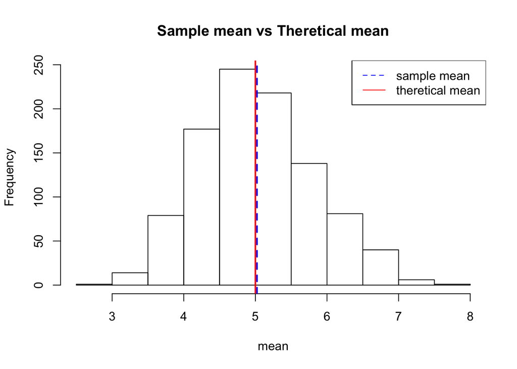

```r
# make plot for the mean of 1000 averages of 40 random exponential distrubutions, and compare sample mean and theretical mean
hist(mns, xlab = "mean",main = "Sample mean vs Theretical mean")
abline(v=smn,col="blue",lwd=2,lty=2)
abline(v=tmn,col="red",lwd=2,lty=1)
legend("topright",lty = c(2,1),col=c("blue","red"),legend=c("sample mean","theretical mean"))
```

#### Sample Variance vs Theoretical Variance

```r
# theretical variance : standard deviation is 1/lambda
tvar <- (1/lambda)^2/n
tvar
```

```
## [1] 0.625
```

```r
# sample variance
svar <- var(mns)
svar
```

```
## [1] 0.6570391
```

#### Distribution: normal?

Use ggplot2 to do this plot

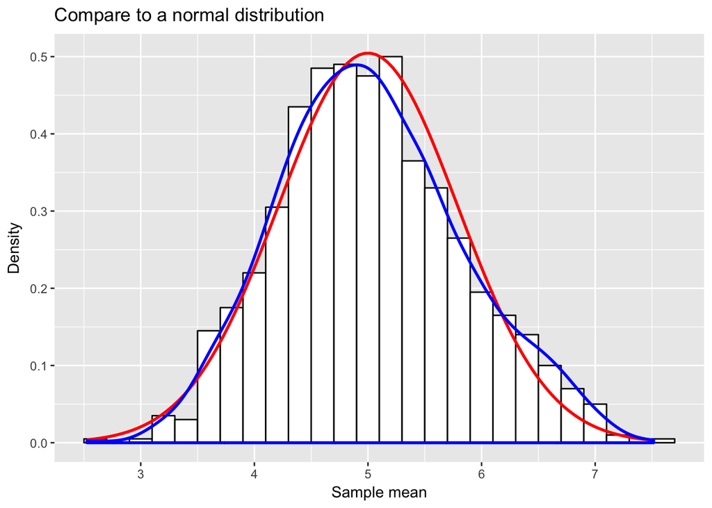

```r
mnsplot <- data.frame(mns)
g1 <- ggplot(data=mnsplot,mapping = aes(x=mns))  +
  geom_histogram(aes(y=..density..),binwidth = 0.2, color = "black", fill = "white") +
  stat_function(fun = dnorm, color = "red",size=1, args = list(mean=tmn,sd=sqrt(tvar))) +
  geom_density(color="blue", size=1) +
  ggtitle("Compare to a normal distribution") +
  xlab("Sample mean") + ylab("Density")
g1
```

We have checked that the mean and variance of the sample distributions are close to those for normal distribution as shown in the figure above. So this distribution is approximately normal.

Note: Normal Q-Q plot can also be used to check if the distribution is normal or not. Details can be refered to the links at the end.

## Part 2: Basic Inferential Data Analysis Instructionsless

Now in the second portion of the project, we’re going to analyze the ToothGrowth data in the R datasets package.

#### Load the ToothGrowth data and perform some basic exploratory data analyses

```r
library(datasets)
data(ToothGrowth)
head(ToothGrowth)
```

```
##    len supp dose
## 1  4.2   VC  0.5
## 2 11.5   VC  0.5
## 3  7.3   VC  0.5
## 4  5.8   VC  0.5
## 5  6.4   VC  0.5
## 6 10.0   VC  0.5
```

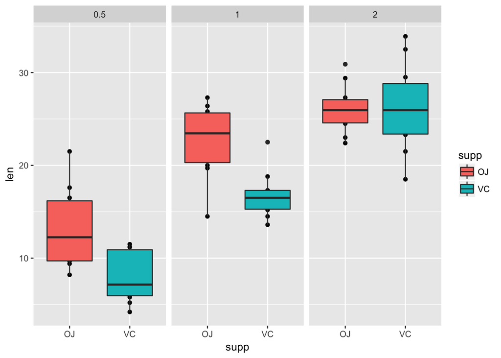

```r
tg <- ToothGrowth
tg$dose <- as.factor(tg$dose)
qplot(x=supp,y=len,data = tg,facets = .~dose) + geom_boxplot(aes(fill = supp))
```

#### Provide a basic summary of the data.

```r
dim(tg)
```

```
## [1] 60  3
```

```r
summary(tg)
```

```
##       len        supp     dose
##  Min.   : 4.20   OJ:30   0.5:20
##  1st Qu.:13.07   VC:30   1  :20
##  Median :19.25           2  :20
##  Mean   :18.81
##  3rd Qu.:25.27
##  Max.   :33.90
```

#### Use confidence intervals and/or hypothesis tests to compare tooth growth by supp and dose.

Note: (Only use the techniques from class, even if there’s other approaches worth considering)

split the dataset according to dose and supp

```r
OJ <- tg[tg$supp == "OJ",]
VC <- tg[tg$supp == "VC",]
OJdose1 <- tg[tg$supp == "OJ" & tg$dose == 0.5,]
OJdose2 <- tg[tg$supp == "OJ" & tg$dose == 1,]
OJdose3 <- tg[tg$supp == "OJ" & tg$dose == 2,]
VCdose1 <- tg[tg$supp == "VC" & tg$dose == 0.5,]
VCdose2 <- tg[tg$supp == "VC" & tg$dose == 1,]
VCdose3 <- tg[tg$supp == "VC" & tg$dose == 2,]
dim(OJ)
```

```
## [1] 30  3
```

```r
dim(VC)
```

```
## [1] 30  3
```

```r
dim(OJdose1)
```

```
## [1] 10  3
```

```r
dim(OJdose2)
```

```
## [1] 10  3
```

```r
dim(OJdose3)
```

```
## [1] 10  3
```

```r
dim(VCdose1)
```

```
## [1] 10  3
```

```r
dim(VCdose2)
```

```
## [1] 10  3
```

```r
dim(VCdose3)
```

```
## [1] 10  3
```

Check if tooth growth is affected by dose

##### Get confidence intervals for different supp regardless different dose

```r
t.test(len ~ supp, data = tg,paired=FALSE, var.equal = FALSE )$conf
```

```
## [1] -0.1710156  7.5710156
## attr(,"conf.level")
## [1] 0.95
```

So when doesn’t consider the dosage, doesn’t show significant difference between two supplements.

##### Get confidence intervals for low/median/large dose with different supp

```r
t.test(OJdose1$len, VCdose1$len, paired = FALSE, var.equal = FALSE)$conf
```

```
## [1] 1.719057 8.780943
## attr(,"conf.level")
## [1] 0.95
```

```r
t.test(OJdose2$len, VCdose2$len, paired = FALSE, var.equal = FALSE)$conf
```

```
## [1] 2.802148 9.057852
## attr(,"conf.level")
## [1] 0.95
```

```r
t.test(OJdose3$len, VCdose3$len, paired = FALSE, var.equal = FALSE)$conf
```

```
## [1] -3.79807  3.63807
## attr(,"conf.level")
## [1] 0.95
```

From the 95% confidence intervals, 0 is not included when the dosage is small or median. So there’s significant difference between two supplement with OJ leads to faster tooth growth than VC.

##### Get confidence intervals for same supp with different dosage

```r
t.test(OJdose1$len, OJdose2$len, paired = FALSE, var.equal = FALSE)$conf
```

```
## [1] -13.415634  -5.524366
## attr(,"conf.level")
## [1] 0.95
```

```r
t.test(OJdose1$len, OJdose3$len, paired = FALSE, var.equal = FALSE)$conf
```

```
## [1] -16.335241  -9.324759
## attr(,"conf.level")
## [1] 0.95
```

```r
t.test(OJdose2$len, OJdose3$len, paired = FALSE, var.equal = FALSE)$conf
```

```
## [1] -6.5314425 -0.1885575
## attr(,"conf.level")
## [1] 0.95
```

```r
t.test(VCdose1$len, VCdose2$len, paired = FALSE, var.equal = FALSE)$conf
```

```
## [1] -11.265712  -6.314288
## attr(,"conf.level")
## [1] 0.95
```

```r
t.test(VCdose1$len, VCdose3$len, paired = FALSE, var.equal = FALSE)$conf
```

```
## [1] -21.90151 -14.41849
## attr(,"conf.level")
## [1] 0.95
```

```r
t.test(VCdose2$len, VCdose3$len, paired = FALSE, var.equal = FALSE)$conf
```

```
## [1] -13.054267  -5.685733
## attr(,"conf.level")
## [1] 0.95
```

From the 95% confidence intervals, 0 is not included in all cases. So there’s significant difference between different dosage of same supplement, the tooth growth becomes faster with increasing dosage.

##### State your conclusions and the assumptions needed for your conclusions.

Assumptions:

- The varience with different supplement and different dosage is not the same.
- The data between different groups are not paired
- The sample population is not skewed

Conclusions:

- With same supplement, OJ or VC, increasing the dosage leads to faster tooth growth
- With small or median dosage, OJ leads to faster tooth growth than VC
- With large dosage, no significant difference observed using OJ or VC

## Review criteria (self check)

- [x] Did you show where the distribution is centered at and compare it to the theoretical center of the distribution?
- [x] Did you show how variable it is and compare it to the theoretical variance of the distribution?
- [x] Did you perform an exploratory data analysis of at least a single plot or table highlighting basic features of the data?
- [x] Did the student perform some relevant confidence intervals and/or tests?
- [x] Were the results of the tests and/or intervals interpreted in the context of the problem correctly?
- [x] Did the student describe the assumptions needed for their conclusions?

##### Links used:

[link 1](https://rpubs.com/gviglioni/ExponentialDistribution_CentralLimitTheorem)  
[link 2](https://rpubs.com/a_inparadise/86939)  
[link 3](https://rpubs.com/abhiuee/53828)  
[link 4](https://rstudio-pubs-static.s3.amazonaws.com/82410_9df3ec9e695c45eda138f47a2fae9187.html)  
[link 5](http://rstudio-pubs-static.s3.amazonaws.com/156585_ea5571a742cc4f1ea94e401a7320c4a4.html)  
[link 6](https://rstudio-pubs-static.s3.amazonaws.com/88003_457d504772954be399c4070d9b404a0f.html)  
[link 7](https://rstudio-pubs-static.s3.amazonaws.com/30490_f5f75fae348843819993bf1e0957f4f1.html)  
[link 8](https://rstudio-pubs-static.s3.amazonaws.com/67663_669e39c2153e4f8295f9d130abf07b7e.html)